# Data Exploration and Visualization

# Trip duration distribution to plot next.

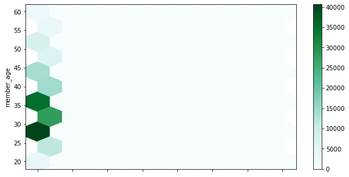

```
count    170186.000000
mean         11.721337
std          27.666547
min           1.016667
50%           8.483333
99%          53.033333
max        1409.133333
Name: duration_minute, dtype: float64
```

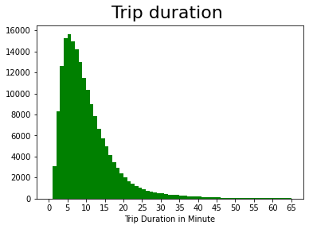

Looks like 99% of the trips were less than 1 hour long with most of them fell between 4 to 10 minutes range. I'll remove the outlier long trips for this study to allow focusing on the most common cases to explore the pattern.

```
<class 'pandas.core.frame.DataFrame'>
Int64Index: 168872 entries, 4 to 183411
Data columns (total 23 columns):
 #   Column                   Non-Null Count   Dtype
---  ------                   --------------   -----
 0   duration_sec             168872 non-null  int64
 1   start_time               168872 non-null  datetime64[ns]
 2   end_time                 168872 non-null  datetime64[ns]
 3   start_station_id         168872 non-null  object
 4   start_station_name       168681 non-null  object
 5   start_station_latitude   168872 non-null  float64
 6   start_station_longitude  168872 non-null  float64
 7   end_station_id           168872 non-null  object
 8   end_station_name         168681 non-null  object
 9   end_station_latitude     168872 non-null  float64
 10  end_station_longitude    168872 non-null  float64
 11  bike_id                  168872 non-null  object
 12  user_type                168872 non-null  category
 13  member_birth_year        168872 non-null  float64
 14  member_gender            168872 non-null  category
 15  bike_share_for_all_trip  168872 non-null  object
 16  duration_minute          168872 non-null  float64
 17  member_age               168872 non-null  float64
 18  start_date               168872 non-null  object
 19  start_hourofday          168872 non-null  object
 20  start_dayofweek          168872 non-null  category
 21  start_month              168872 non-null  object
 22  age_bins                 168872 non-null  object
dtypes: category(3), datetime64[ns](2), float64(7), int64(1), object(10)
memory usage: 27.5+ MB
```

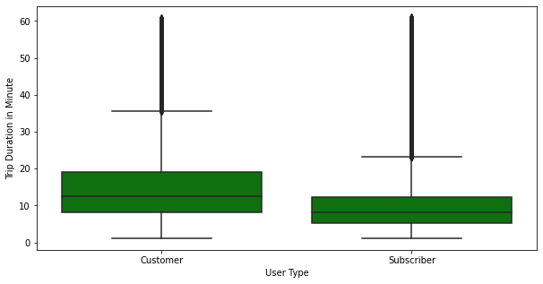

How does the trip duration distribution vary by gender?

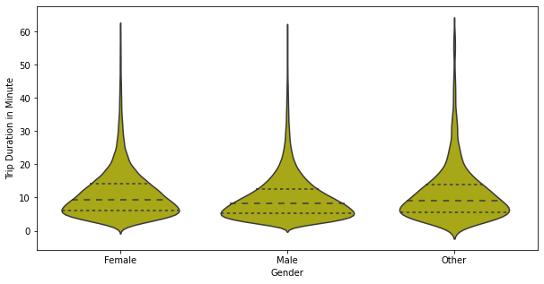

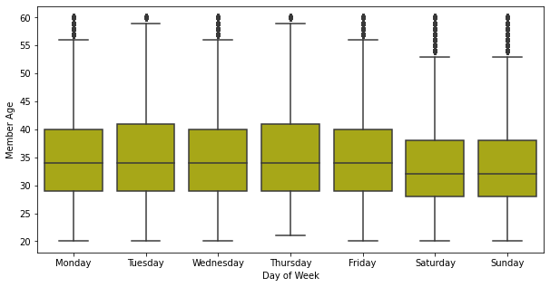

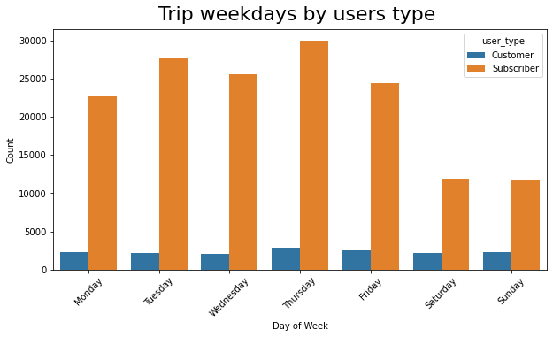

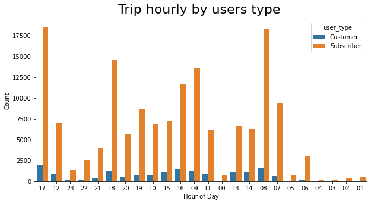

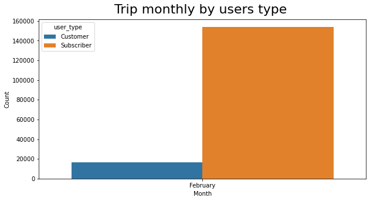

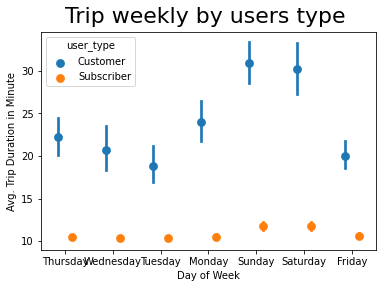

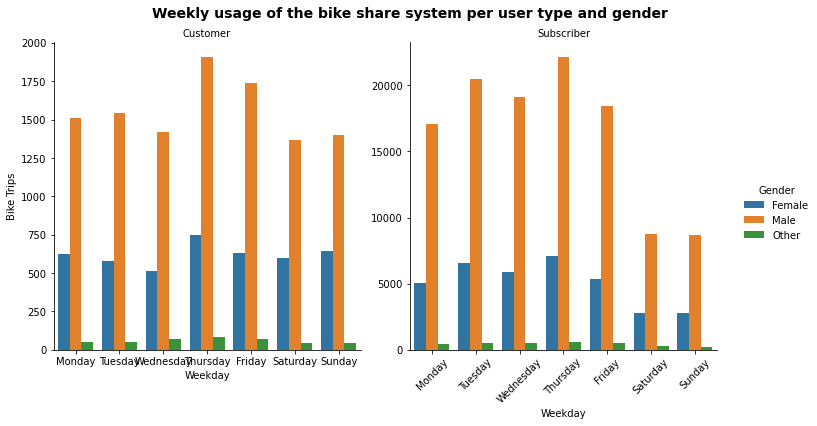

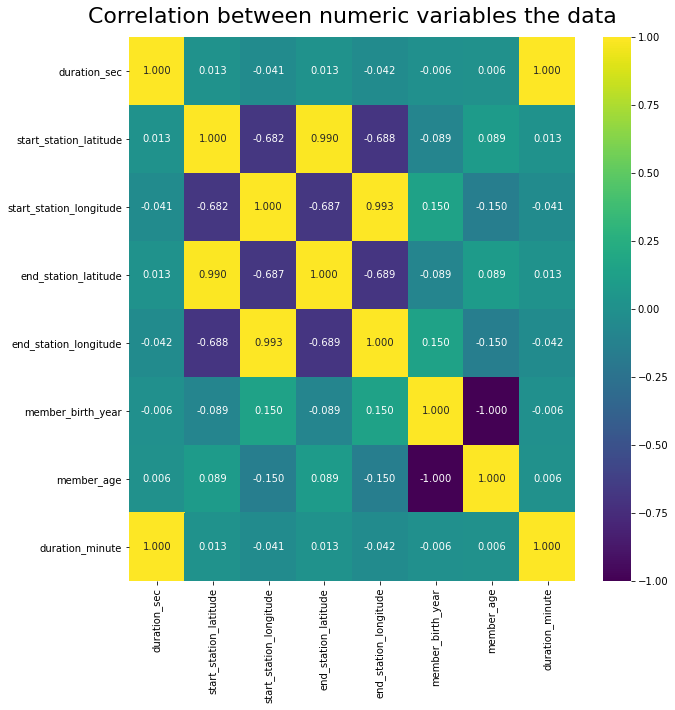